# Analysis of Red Wine Quality

Mohamed Alsayed

26 November, 2019

This tidy data set contains 1,599 red wines with 11 variables on the chemical properties of the wine. At least 3 wine experts rated the quality of each wine, providing a rating between 0 (very bad) and 10 (very excellent).

# 1 Univariate Plots Section

```
##    Min. 1st Qu.  Median    Mean 3rd Qu.    Max.
##   3.000   5.000   6.000   5.636   6.000   8.000
```

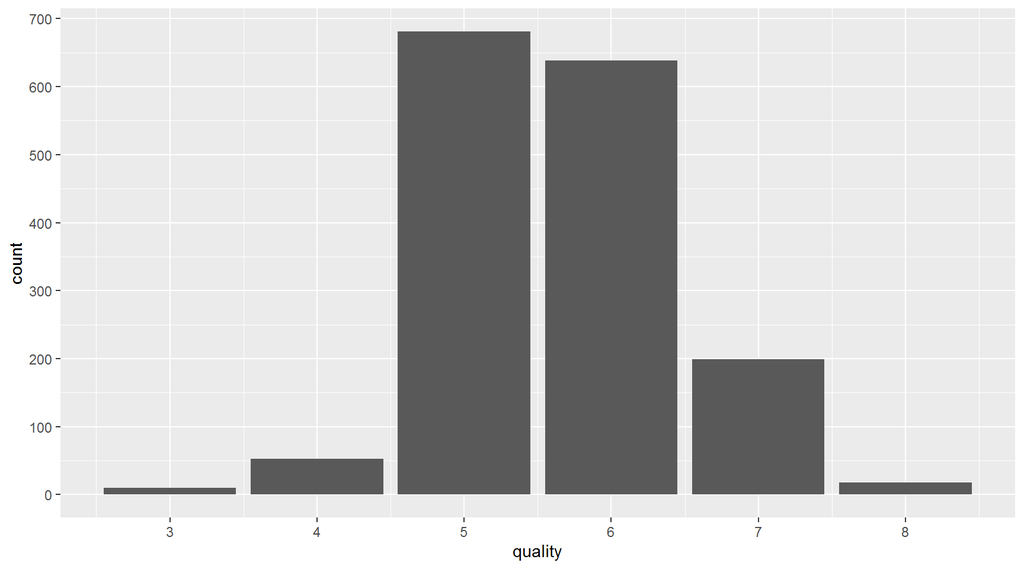

```
##    Min. 1st Qu.  Median    Mean 3rd Qu.    Max.
##    4.60    7.10    7.90    8.32    9.20   15.90
```

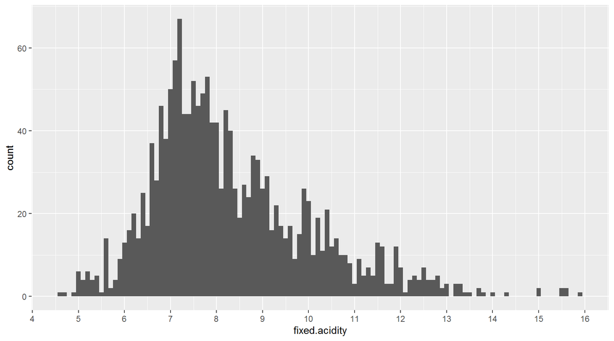

The fixed acidity histogram show that the majority of wine samples has fixed acidity of apporximately 7 to 8 and the rest ranges between 4.5 to 13 and few of the samples has higher fixed acidity above 13 to 16.

```
##    Min. 1st Qu.  Median    Mean 3rd Qu.    Max.
##  0.1200  0.3900  0.5200  0.5278  0.6400  1.5800
```

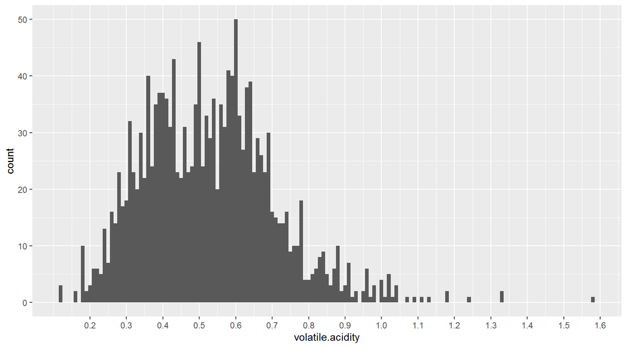

The volatile acidity histogram show that the majority of wine samples has volatile acidity of 0.3 to 0.7

```
##    Min. 1st Qu.  Median    Mean 3rd Qu.    Max.
##   0.000   0.090   0.260   0.271   0.420   1.000
```

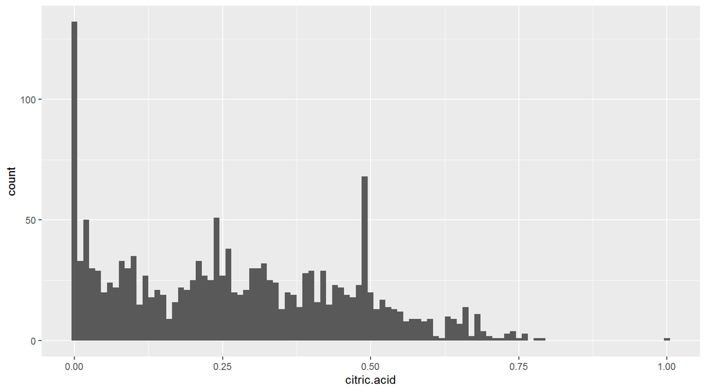

The Citric Acid histogram shows that the majority of wine samples ranges between 0 and 0.75 and also we can observe high number of these samples has 0 citric acid as well as 0.5 citric acid.

```
##    Min. 1st Qu.  Median    Mean 3rd Qu.    Max.
##   0.900   1.900   2.200   2.539   2.600  15.500
```

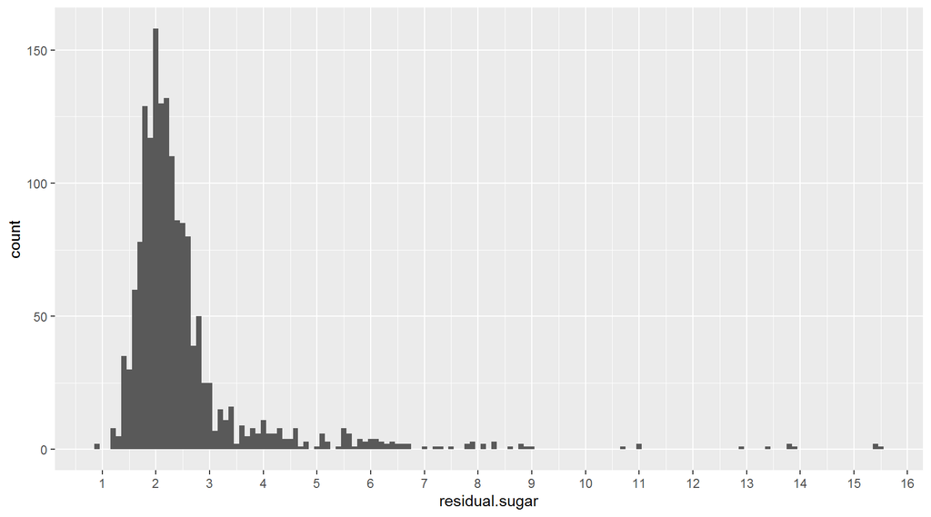

The Residual Sugar histogram shows that most of wine samples are between 2 and 3 on residual sugar and some few samples above 4 to 16.

```
##    Min. 1st Qu.  Median    Mean 3rd Qu.    Max.
## 0.01200 0.07000 0.07900 0.08747 0.09000 0.61100
```

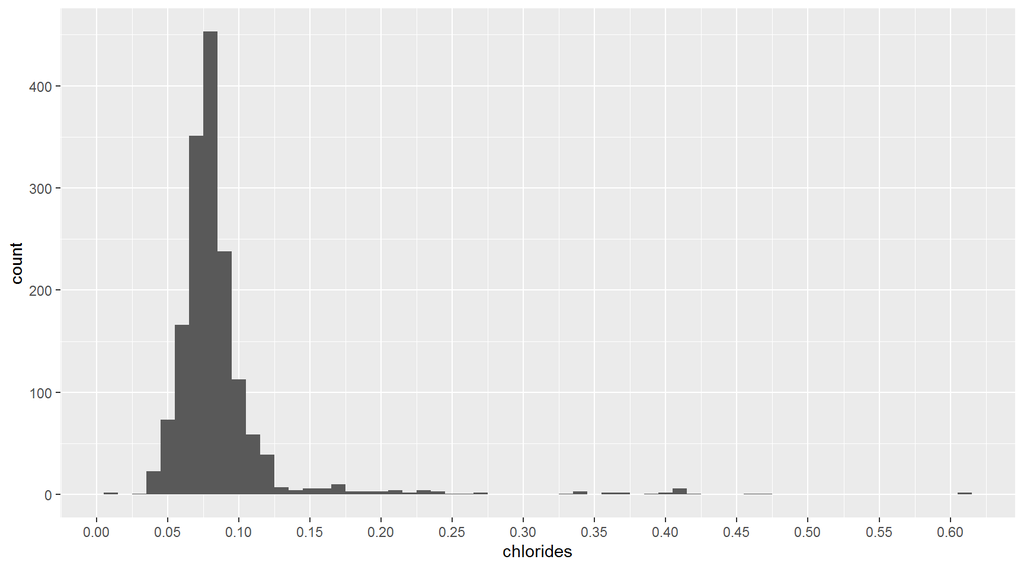

The Chlorides histogram shows that the majority of wine samples are between 0.05 to 0.1 on the chlorides scale.

```
##    Min. 1st Qu.  Median    Mean 3rd Qu.    Max.
##    1.00    7.00   14.00   15.87   21.00   72.00
```

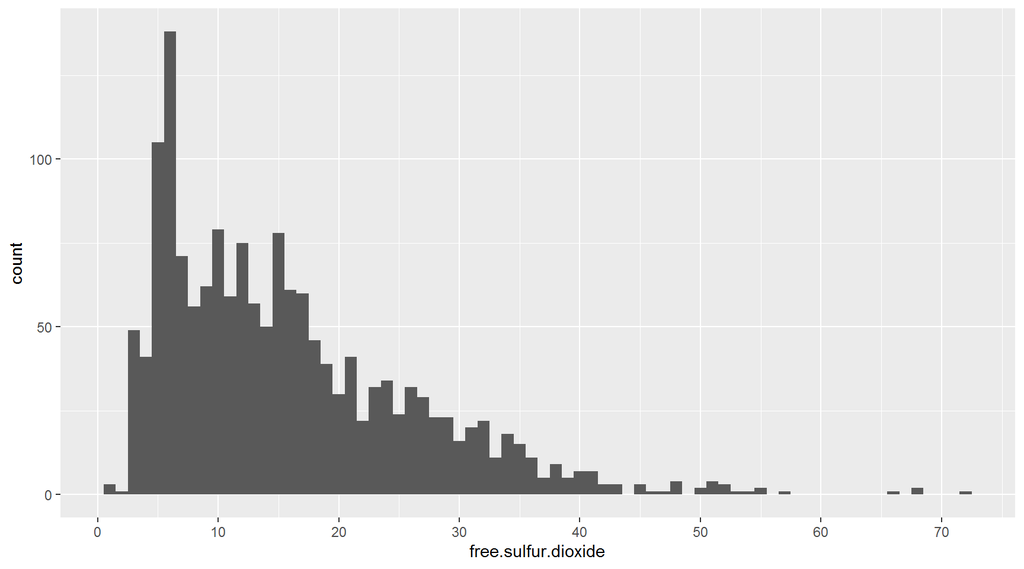

The Free Sulfur Dioxide histogram shows that the wine samples ranges between 0 to 50 and many samples has 5 value on the free sulfur dioxide scale.

```
##    Min. 1st Qu.  Median    Mean 3rd Qu.    Max.
##    6.00   22.00   38.00   46.47   62.00  289.00
```

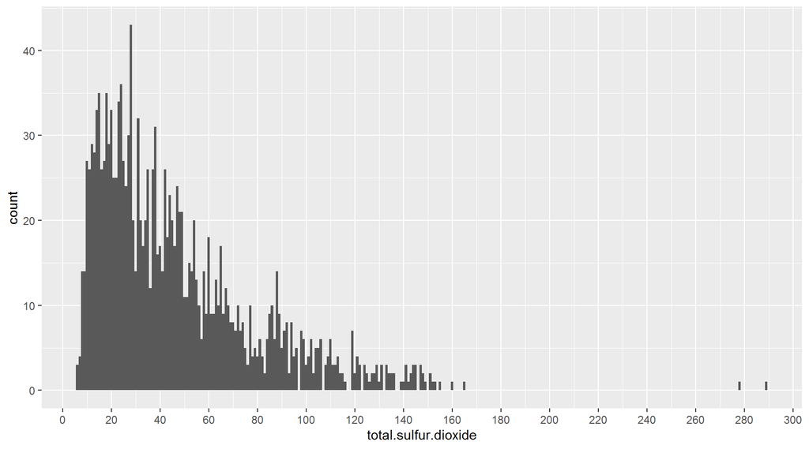

The total Sulfur Dioxide histogram shows that the majority of wine samples ranges between 10 to 120 and there are some outliers above 260 .

```
##    Min. 1st Qu.  Median    Mean 3rd Qu.    Max.
##  0.9901  0.9956  0.9968  0.9967  0.9978  1.0037
```

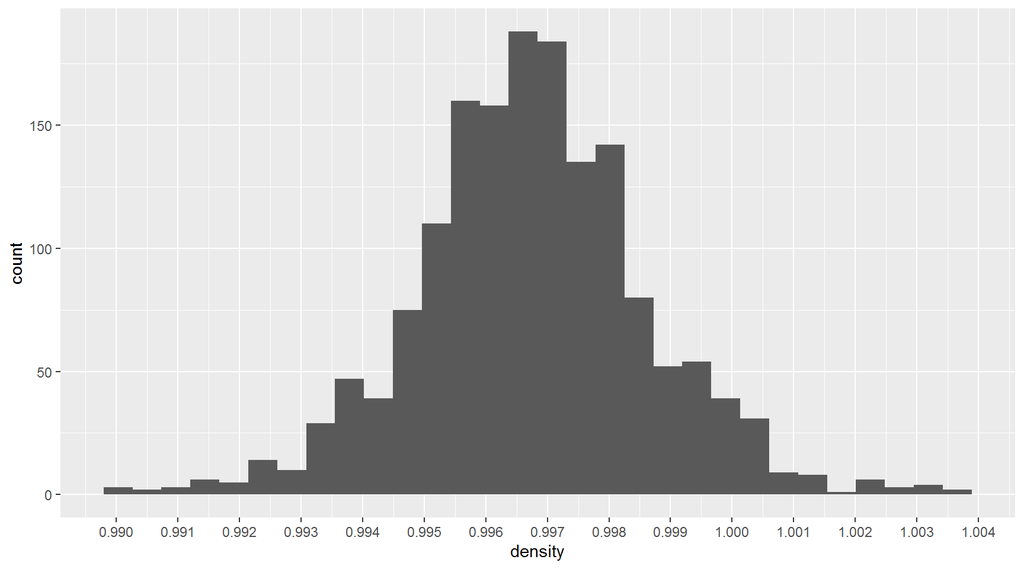

The density histogram shows a nearly normal distrbuted data with a peak of 0.997 and range between 0.990 to 1.004

```
##    Min. 1st Qu.  Median    Mean 3rd Qu.    Max.
##   2.740   3.210   3.310   3.311   3.400   4.010
```

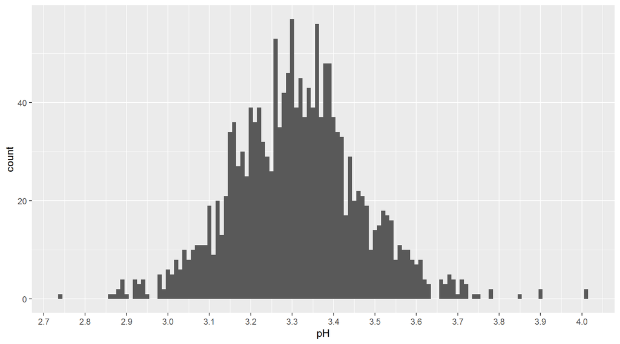

The Ph histogram shows that most wine sample has ph value that ranges between 3 to 3.7 and some of the outlier samples are above 4.

```
##    Min. 1st Qu.  Median    Mean 3rd Qu.    Max.
##  0.3300  0.5500  0.6200  0.6581  0.7300  2.0000
```

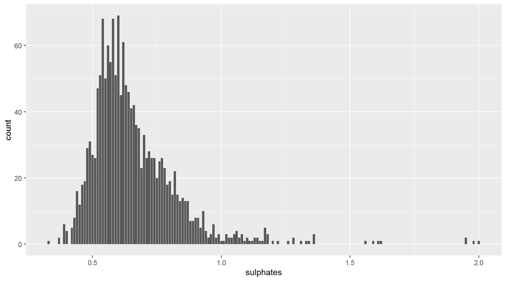

The sulphates histogram shows that most of wine samples are ranging between 0.5 to 1.

```
##    Min. 1st Qu.  Median    Mean 3rd Qu.    Max.
##    8.40    9.50   10.20   10.42   11.10   14.90
```

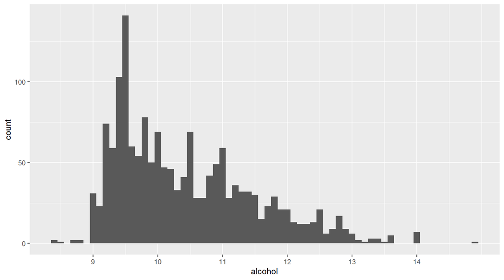

The Alcohol histogram shows that the wine samples has alcohol ranges between 9 to 14 with a high number of samples contains 9.5 of alcohol.

# 2 Univariate Analysis

### 2.0.1 What is the structure of your dataset?

The dataset consist of 11 variables that contribute in the red wine quality like alcohol, ph and density.

### 2.0.2 What is/are the main feature(s) of interest in your dataset?

The most interesting variable is alcohol since its the main factor contributing directly to the quality of the red wine.

### 2.0.3 What other features in the dataset do you think will help support your

investigation into your feature(s) of interest? The ph value as well as the density of the wine will both be good factors to detrmine the wine quality.

### 2.0.4 Did you create any new variables from existing variables in the dataset?

I measured every variable independently to be able to see its effect on the quality and no new variables has been added.

### 2.0.5 Of the features you investigated, were there any unusual distributions?

Did you perform any operations on the data to tidy, adjust, or change the form  
of the data? If so, why did you do this? The data is pretty tidy and has no errors nor nulls but distributions just needed some adjustment for readability so I changed the bin width for most of histograms and adjusted their axis for better observations.

# 3 Bivariate Plots Section

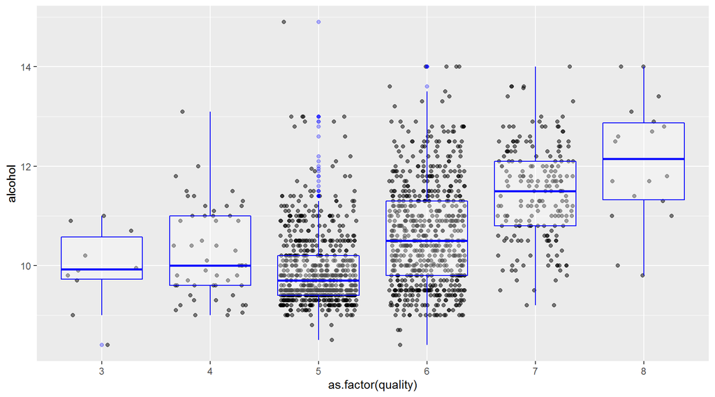

The plot above shows the relation between alcohol and the quality of red wine, and we can observe that the quality increases when alcohol increases.

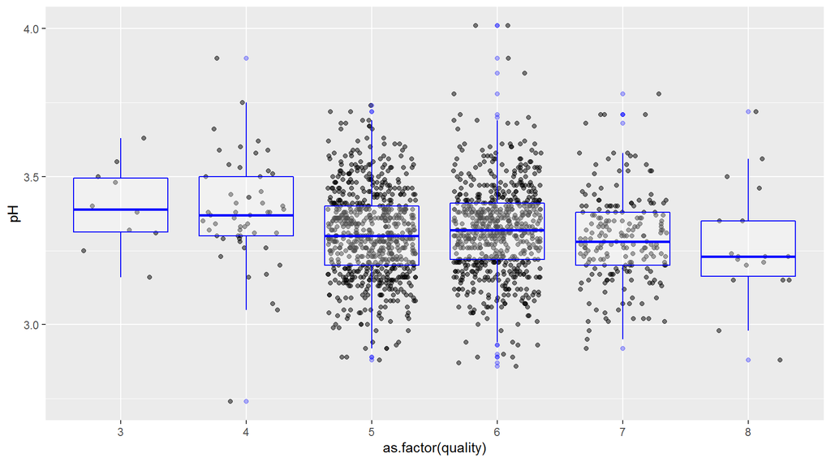

The relation between pH and the quality are week and the plot shows that high pH can get nearly same result as lower pH in quality.

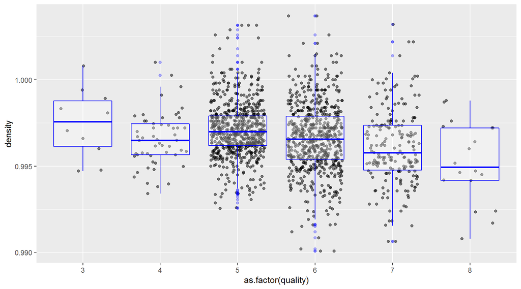

The plot above showing the relation between quality and density, we can observe that there is an inverse relation when density increases the quality decreases and vice versa.

# 4 Bivariate Analysis

### 4.0.1 Talk about some of the relationships you observed in this part of the

investigation. How did the feature(s) of interest vary with other features in  
the dataset?

-Alcholol has big impact on the quality level of the red wine, we can see from the plotted data that the increase of alchohol increases the chance of high quality rates. -Density has inverse relation with the quality when the density increases the quality decreases -The pH value of the red wine did not show much relation and effect on the quality rate of the red wine.

### 4.0.2 Did you observe any interesting relationships between the other features

(not the main feature(s) of interest)?

Yes, both density and pH values and how both impacted the change in quality rates across all red wine samples.

### 4.0.3 What was the strongest relationship you found?

-Alcohol has strongest relationship to the quality rate of the red wine.

# 5 Multivariate Plots Section

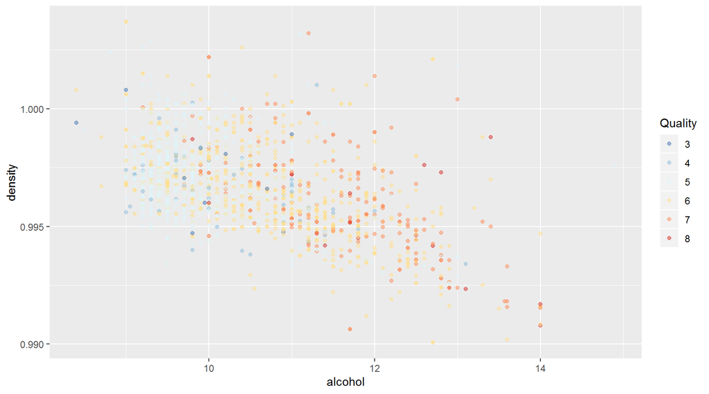

From the scatterplot above we can observe the inverse relation between density and alcohol, when density increases the alcohol decreases. we can also see that the quality of red wine is assosicated with high level of alcohol and lower density values which proves previous investigation.

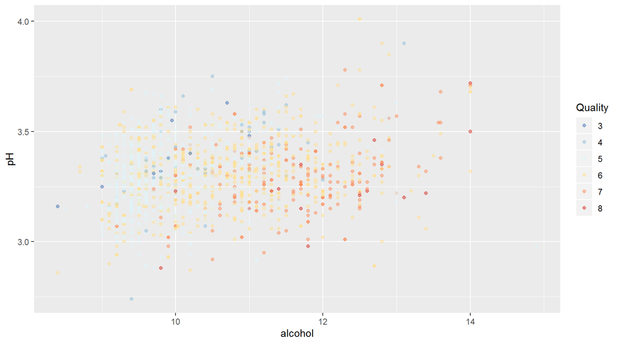

The above scatterplot shows a weak relationship between pH value and alcohol most samples scores between 3 to 3.5 pH and associated with 10 alcohol value and the increase in alcohol associated with more quality rates.

# 6 Multivariate Analysis

### 6.0.1 Talk about some of the relationships you observed in this part of the

investigation. Were there features that strengthened each other in terms of  
looking at your feature(s) of interest?

The Density, alcohol and quality scatterplot strenghtened the previous observed data from the bivariate section and showed how both of those two factors contributed in the red wine quality rating.

### 6.0.2 Were there any interesting or surprising interactions between features?

The pH value of the red wine has no effect on the quality results nor even has a clear relationship with alcohol which is surprising.

# 7 Final Plots and Summary

### 7.0.1 Plot One

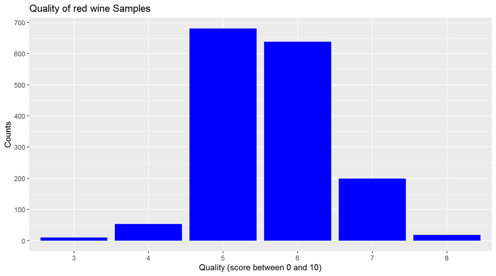

### 7.0.3 Plot Two

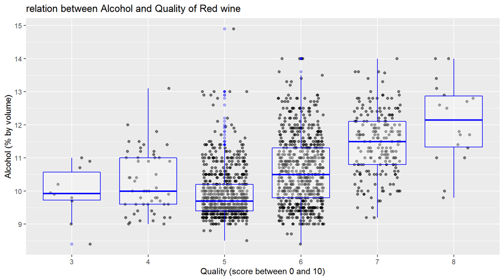

### 7.0.4 Description Two

The plot above shows the relation between alcohol and the quality of red wine, and we can observe that the quality increases when alcohol increases.

### 7.0.5 Plot Three

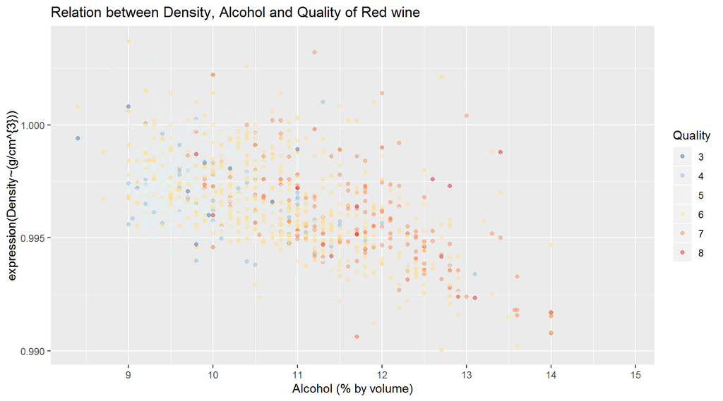

# 8 Reflection

The Red wine database contains around 1600 sample of red wine data and all of their chemical combinations, with these data we performed a high level data analysis to understand how much every variable of these chemicals contribute the most in each sample quality.

Our observation from these data that some variables has big impact on the quality rating and some other not for instance, alcohol showed a propotional relationship toward the quality whenever the alcohol increases the quality increases. Another factor which has big impact on quality is the density of the red wine sample it has inverse relationship with the quality, when the density increases the quality decreases and the alcohol value as well.

Furthermore, for future analysis we might use logestic regression analysis for better analysing the red wine quality.